# Predicting Tax Compliance

Author

Runqi Liu

Published

April 6, 2023

In this project I will work with data from Malawi on tax compliance. The goal is to predict whether a market vendor reports paying a market tax or not based on a large number of demographic variables.

The data, contained in data/vendor_data.RData, come from a project Dr. Simon Hoellerbauer has been working on that analyzes a randomized control trial (RCT) focused on tax compliance carried out in Malawi. In Malawi, market vendors have to pay a fee (a flat tax) in order to be able to sell goods or services in a market. This fee is collected by fee collectors, who make the rounds each day. Compliance is not optimal for a variety of reasons, a main one being that markets are underfunded and so are often in poor conditions. This causes market vendors to not want to pay the market tax, which in turn makes it harder for the government to improve the markets (this is called a vicious cycle). The RCT ran from October 2017 to March 2019 in 128 markets in 8 districts in Malawi. The goal of the RCT was to investigate different ways to break out of this vicious cycle in Malawian markets.

The data was collected via an in-person survey of market vendors carried out between October 2018 and January 2019. In total, 12,370 market vendors completed the survey. 2,531 of these vendors were asked a longer form of the survey, with more questions. We will be working with the responses from these individuals for this homework.

The key outcome is recent_receipt_7. This captures whether a respondent was able to present a receipt for paying taxes (which fee collectors are supposed to hand out after receiving the market tax) to their interviewer. It is a binary variable.

## Codebook

```r
library(glue)
library(tidyverse)
```

| Variables | Description | Value |
| --- | --- | --- |
| `market` | Market ID of respondent’s market | Numeric 1 to 128 for privacy reasons, but represents a categorical value. **Note**: You will have to turn this into a factor/categorical variable, or **scikit-learn will get confused**! |
| `district` | District ID of district where respondent’s market is located | Numeric 1 to 8 for privacy reasons, but represents a categorical value. **Note**: You will have to turn this into a factor/categorical variable, or **scikit-learn will get confused**! |
| `language` | Language in which survey was carried out | Factor with levels *Chichewa, English, Tumbuka, Yawo* |
| `female` | Is respondent female or not (Note: assessed by interviewer) | Binary. 1 = Female, 0 = Not Female |
| `age` | Respondent’s age | Numeric |
| `tribe` | Respondent’s tribe | Factor with levels *Chewa, Lomwe, Ngoni, Yao, Tumbuka, Sena, Tonga* |
| `married` | Is respondent married? | Binary. 1 = Yes, 0 = No |
| `education` | Maximum level of education completed by respondent | Factor with 18 levels from ‘None’ to ‘PhD’ |
| `educ_num` | Numeric version of education variable | Because `education` is ordered, this roughly captures how educated respondent is numerically. Note that it does not quite correspond to how many years of education a respondent has completed. |
| `literacy` | How well respondent was able to read a cue card. Used as a measure of literacy. | Factor with levels *Could not read, Could read some of the card, Could read the whole card with difficulty, Could read the whole card with ease* |
| `reading_language` | Language in which respondent wanted to read cue card | Factor with levels *Chichewa, English, Could not read* |
| `houses` | How many houses are owned by respondent’s household | Numeric |
| `acres_farmland` | How many acres of farmland are owned by respondent’s household | Numeric |
| `bicycles` | How many bicycles are owned by respondent’s household | Numeric |
| `chickens` | How many chickens are owned by respondent’s household | Numeric |
| `goats` | How many goats are owned by respondent’s household | Numeric |
| `basic_cell_phones` | How many basic cell phones are owned by the respondent’s household | Numeric |
| `smart_phones` | How many smart phones are owned by the respondent’s household | Numeric |
| `days_pr_week` | How many days a week respondent sells at this market | Numeric |
| `service` | Does vendor sell services or goods | Binary. 1 = Service, 0 = Good |
| `yrs_in_mkt_fix` | How many years respondent has sold at this market | Numeric |
| `profit` | Respondent’s average daily profit (in Malawian kwacha) | Numeric |
| `profit_lst_yr_month` | How their profit this month compares to their profit this month last year | Factor with levels *Much lower (less than 1/2, Lower (less, but not 1/2), Same, More (more but not double), Much higher (more than double)* |
| `hh_income_trim_99` | Respondent’s household income (Note: this has been 99th percentile trimmed, where extreme values higher than the 99th percentile are dropped, as a way to reduce outliers. (Malawian kwacha) | Numeric |
| `customers_pr_day_trim_99` | How many customers respondent has a day, on average (Note: 99th percentile trimmed) | Numeric |
| `stall_type` | A description of the respondent’s stall (spot in the market) | Factor with levels *Tarp, blanket or baskets on the ground; Tempoarary stall or tablet that gets put up and taken down every day; Uncovered permanent stall; Covered permanent stall WITHOUT lock; Cover… |
| `vote_intend` | Does respondent intend to vote in 2019 presidential election? | Binary. 1 = Yes, 0 = No |
| `recent_receipt_7` | Did respondent show enumerator from within past 7 days? | Binary. 1 = Yes, 0 = No |
| `unequal_test` | Should this be part of the test set for question 6? | Binary. 1 = Test, 0 = Training |

## Packages

```r
library(reticulate)
library(tidyverse)
library(ggplot2)
```

```python
import pandas as pd
import numpy as np
import seaborn as sns
import matplotlib.pyplot as plt
from sklearn.preprocessing import StandardScaler, OneHotEncoder
from sklearn.pipeline import Pipeline
from sklearn.compose import make_column_transformer
from sklearn.model_selection import cross_val_predict, train_test_split, GridSearchCV, StratifiedShuffleSplit
from sklearn.datasets import make_regression
from sklearn.metrics import roc_auc_score
from sklearn.kernel_approximation import Nystroem
from sklearn.linear_model import SGDClassifier
from sklearn.ensemble import GradientBoostingClassifier
```

## Data Visualization

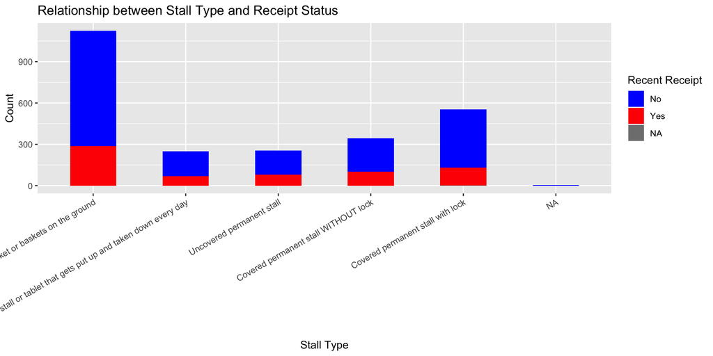

```r
load('data/vendor_data.RData')

# convert the recent_receipt column into categorical column
vendor_data$recent_receipt_7 <- factor(vendor_data$recent_receipt_7)

# creating bar plot that reflects the relationship between stall type and receipt status
ggplot(vendor_data, aes(x = stall_type, fill = recent_receipt_7, group = recent_receipt_7)) +
  geom_bar(width = 0.5) +
  labs(title = "Relationship between Stall Type and Receipt Status",
       x = "Stall Type",
       y = "Count",
       fill = "Recent Receipt") +
  theme(axis.text.x = element_text(angle = 30, hjust = 1))+
  scale_fill_manual(labels = c("No", "Yes"), values = c("blue", "red"))
```

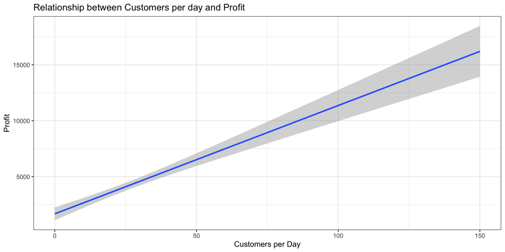

```r
# creating a plot that reflects the relationship between customers per daya the profit
ggplot(vendor_data, aes(x = customers_pr_day_trim_99, y = profit)) +
  geom_smooth(method=lm) +
  labs(title = "Relationship between Customers per day and Profit",
       x = "Customers per Day",
       y = "Profit") +
  theme_bw()
```

## Train-Test Split

```python
# drop NAs from the data and converting the data set into a pandas data frame
vendor = r.vendor_data.dropna()
vendor = pd.DataFrame(vendor)

# create X and y
X = vendor.drop(['recent_receipt_7', 'unequal_test', 'market'], axis=1)
y = np.ravel(vendor['recent_receipt_7'])

# create a train-test split
X_train, X_test, y_train, y_test = train_test_split(
  X,
  y,
  test_size = 0.25,
  random_state = 20
)
```

In this code chunk, I dropped all NAs because missing values can cause issues when fitting models because many algorithms are not able to handle missing data.

## Support Vector Machine

Find the optimal support vector machine for predicting a recent receipt using all of our variables.

```python
categorical_cols = ['language', 'district', 'tribe','education','literacy','reading_language','profit_lst_yr_month','stall_type']
binary_cols = ['female', 'married', 'vote_intend', 'service']
numeric_cols = list(X.columns)
numeric_cols = [c for c in numeric_cols if c not in binary_cols]
numeric_cols = [c for c in numeric_cols if c not in categorical_cols]

# create a preprocessor
preprocessor = make_column_transformer(
  (OneHotEncoder(drop="if_binary"), categorical_cols),
  (StandardScaler(), numeric_cols),
  remainder = "passthrough",
  verbose_feature_names_out = False
  )

# Set ranges for the hyperparameters
alpha_range = np.logspace(-4, 4, 10)
gamma_range = np.logspace(-4, 4, 10)
kernels = ['rbf', 'linear']

# Set the hyperparameters to be tuned in a dictionary
param_grid_svm = dict(
  kernel_approx__gamma=gamma_range, kernel_approx__kernel = kernels,
  estimator__alpha = alpha_range
)

# Set the cross-validation object
cv = StratifiedShuffleSplit(n_splits=5, random_state = 100)

# Create a pipeline object that applies the preprocessor, kernel approximation, and the SGDClassifier estimator
pipeline_svm = Pipeline(
  [
    ('preprocess', preprocessor),
    ('kernel_approx', Nystroem()),
    ('estimator', SGDClassifier(loss = 'hinge', random_state = 102))
  ]
)

# Perform grid search with cross-validation
grid_svm = (
  GridSearchCV(pipeline_svm, param_grid=param_grid_svm, cv=cv, scoring='roc_auc')
  .fit(X_train, y_train)
)

# Print the best hyperparameters and the corresponding AUC score
print(
    "The best parameters are %s, with a score of %0.2f"
    % (grid_svm.best_params_, grid_svm.best_score_)
)
```

```
The best parameters are {'estimator__alpha': 0.0001, 'kernel_approx__gamma': 0.005994842503189409, 'kernel_approx__kernel': 'rbf'}, with a score of 0.72
```

We can use ROC curve AUC because it is a measure of the classifier’s ability to correctly classify positive and negative samples, regardless of the threshold used to make the classification decision.

```python
# calculating overall AUC
roc_auc_overall = roc_auc_score(y_test, grid_svm.best_estimator_.decision_function(X_test))

# spliting test data into married and unmarried groups
X_test_married = X_test.loc[X_test['married']==1]
X_test_unmarried = X_test.loc[X_test['married']==0]
y_test_married = y_test[X_test['married']==1]
y_test_unmarried = y_test[X_test['married']==0]

# calculating married AUC
roc_auc_married = roc_auc_score(y_test_married, grid_svm.best_estimator_.decision_function(X_test_married))

# calculating unmarried AUC
roc_auc_unmarried = roc_auc_score(y_test_unmarried, grid_svm.best_estimator_.decision_function(X_test_unmarried))

print(
    f'The AUC on the overall test set is {roc_auc_overall}. The AUC on the married subsample is  {roc_auc_married}. The AUC on the unmarried subsample is {roc_auc_unmarried}.'
)
```

```
The AUC on the overall test set is 0.7052478926855795. The AUC on the married subsample is  0.6931286549707603. The AUC on the unmarried subsample is 0.7306122448979592.
```

Yes, the AUC for the subsample of the test set who are married is different from that for the subsample who are not married. This could mean that there is a different relationship between the predictor variables and the target variable for those who are married vs. those who are not.

## Gradient Boosting Machine

Find the optimal gradient boosting machine for predicting a recent receipt using all of our variables.

```python
# setting parameters
b = np.arange(5000, 8000, 1000)
lamb = [0.001, 0.01]
d = np.arange(1, 3)

param_grid_gbm = dict(
  gbm__n_estimators = b,
  gbm__learning_rate = lamb,
  gbm__max_depth = d
)

# creating a pipeline
pipeline_gbm = Pipeline(
  [
    ('preprocess', preprocessor),
    ('gbm', GradientBoostingClassifier(random_state = 0, subsample = 0.5))
  ]
)

# Perform grid search with cross-validation
grid_gbm = (
  GridSearchCV(pipeline_gbm,
              param_grid=param_grid_gbm,
              cv=cv,
              scoring='roc_auc').fit(X_train, y_train)
)
```

```python
print(
    "The best parameters are %s with a score of %0.2f"
    % (grid_gbm.best_params_, grid_gbm.best_score_)
)
```

```
The best parameters are {'gbm__learning_rate': 0.001, 'gbm__max_depth': 2, 'gbm__n_estimators': 7000} with a score of 0.73
```

```python
roc_auc_gbm = roc_auc_score(y_test, grid_gbm.best_estimator_.decision_function(X_test))
print(f'The AUC on the overall test set is {roc_auc_gbm}.')
```

```
The AUC on the overall test set is 0.7412535121907006.
```

This AUC is higher than the AUC for SVM. Therefore, GBM does better at predicting on unseen data.

## With Not Randomly Selected Training Data

For this question, we will be working with a different train-test split. Split up the data into X_train_new, X_test_new, y_train_new, and y_test_new based on the unequal_test column. If this variable = 1, then it should go into the new test set. I picked GBM that produced the best performance on the test data. Find the best model of this kind using the new training data again using grid search.

```python
# Split up the data into X_train_new, X_test_new, y_train_new, and y_test_new based on the unequal_test column
vendor_1 = vendor[vendor["unequal_test"] == 1]
vendor_0 = vendor[vendor["unequal_test"] == 0]

X_train_new = vendor_0.drop(["recent_receipt_7", "unequal_test", "market"], axis = 1)
X_test_new = vendor_1.drop(["recent_receipt_7", "unequal_test", "market"], axis = 1)
y_train_new = np.ravel(vendor_0["recent_receipt_7"])
y_test_new = np.ravel(vendor_1["recent_receipt_7"])

# Perform grid search with cross-validation
grid_gbm_new = (
  GridSearchCV(pipeline_gbm, param_grid=param_grid_gbm, cv=cv,
  scoring = 'roc_auc')
  .fit(X_train_new, y_train_new)
)

print(
    "The best parameters are %s with a score of %0.2f"
    % (grid_gbm_new.best_params_, grid_gbm_new.best_score_))

# calculating the AUC on the new data
```

```
The best parameters are {'gbm__learning_rate': 0.001, 'gbm__max_depth': 2, 'gbm__n_estimators': 7000} with a score of 0.73
```

```python
roc_auc_gbm_new = roc_auc_score(y_test_new, grid_gbm_new.best_estimator_.decision_function(X_test_new))
print(
    f'The AUC on the data the model hasn’t seen yet is {roc_auc_gbm_new}.'
)
```

```
The AUC on the data the model hasn’t seen yet is 0.6478747315736261.
```

This seems worse than the overall test AUC when we randomly split our data into test and training sets. It might be because the training and testing subsets have significantly different distributions for some variables, then the model may not be able to generalize well to the testing subset, resulting in a lower AUC. Also, the new training data set has a smaller size than the old training set, then there may not be enough data to train the model effectively, resulting in a lower AUC. This implies that it is important to ensure that the training and testing subsets have a similar distribution of data to ensure that the model can generalize well to new data.

```python
# Define a function to calculate the proportion
def calculate_proportion(group):
    group['prop'] = group['n'] / group['n'].sum()
    return group

# language
language = (vendor.groupby(['unequal_test', 'language'])
      .size().reset_index(name='n')
      .groupby('unequal_test').apply(calculate_proportion))

# district
district = (vendor.groupby(['unequal_test', 'district'])
      .size().reset_index(name='n')
      .groupby('unequal_test').apply(calculate_proportion))

# stall_type
stall_type = (vendor.groupby(['unequal_test', 'stall_type'])
      .size().reset_index(name='n')
      .groupby('unequal_test').apply(calculate_proportion))

print(language)
```

```
   unequal_test  language     n      prop
0             0  Chichewa  1195  0.947661
1             0   English     0  0.000000
2             0   Tumbuka    66  0.052339
3             0      Yawo     0  0.000000
4             1  Chichewa   698  0.991477
5             1   English     0  0.000000
6             1   Tumbuka     6  0.008523
7             1      Yawo     0  0.000000
```

```python
print(district)
```

```
    unequal_test  district    n      prop
0              0       1.0   14  0.011102
1              0       2.0    6  0.004758
2              0       3.0  338  0.268041
3              0       4.0  237  0.187946
4              0       5.0  325  0.257732
5              0       6.0  104  0.082474
6              0       7.0   36  0.028549
7              0       8.0  201  0.159397
8              1       1.0  158  0.224432
9              1       2.0  118  0.167614
10             1       3.0   41  0.058239
11             1       4.0   30  0.042614
12             1       5.0   36  0.051136
13             1       6.0   14  0.019886
14             1       7.0  287  0.407670
15             1       8.0   20  0.028409
```

```python
print(stall_type)
```

```
   unequal_test  ...      prop
0             0  ...  0.447264
1             0  ...  0.083267
2             0  ...  0.107058
3             0  ...  0.139572
4             0  ...  0.222839
5             1  ...  0.446023
6             1  ...  0.130682
7             1  ...  0.107955
8             1  ...  0.137784
9             1  ...  0.177557

[10 rows x 4 columns]
```

District is the most unbalanced variable. Many categories in this variable are very unbalanced in the train and test sets.

## Introspection

There could be several downsides to predicting whether a Malawian market vendor will pay the market tax or not. Here are some potential downsides:

Privacy concerns: Predicting whether someone will pay a tax or not could involve collecting and analyzing personal data. This could raise concerns around privacy and the ethical use of personal information.

Unintended consequences: The prediction of whether someone will pay a tax or not could lead to unintended consequences. For example, vendors who are predicted not to pay the tax may be targeted by the government or face increased scrutiny, even if they intend to pay the tax.

Overall, prediction of this kind could have both positive and negative consequences. While it could potentially help the government identify shirkers and increase revenue, it could also raise concerns around privacy, biases, and unintended consequences. It is important to weigh these factors carefully and consider the potential impact on all stakeholders before implementing such a prediction task.